# Reproducible Research: Peer Assessment 1

## Loading and preprocessing the data

The data will be read into a variable named ‘data’.

```r
data <- read.csv(unz("activity.zip", 'activity.csv'))
```

Import libraries.

```r
library(dplyr)
library(xtable)
library(ggplot2)
```

## What is mean total number of steps taken per day?

**1. Total number of steps** Total steps per day is:

```r
total_daily_steps <- summarise(
  group_by(data, date),
  daily_steps = sum(steps, na.rm = TRUE)
  )
print(xtable(total_daily_steps), type='html')
```

|  | date | daily_steps |
| --- | --- | --- |
| 1 | 2012-10-01 | 0 |
| 2 | 2012-10-02 | 126 |
| 3 | 2012-10-03 | 11352 |
| 4 | 2012-10-04 | 12116 |
| 5 | 2012-10-05 | 13294 |
| 6 | 2012-10-06 | 15420 |
| 7 | 2012-10-07 | 11015 |
| 8 | 2012-10-08 | 0 |
| 9 | 2012-10-09 | 12811 |
| 10 | 2012-10-10 | 9900 |
| 11 | 2012-10-11 | 10304 |
| 12 | 2012-10-12 | 17382 |
| 13 | 2012-10-13 | 12426 |
| 14 | 2012-10-14 | 15098 |
| 15 | 2012-10-15 | 10139 |
| 16 | 2012-10-16 | 15084 |
| 17 | 2012-10-17 | 13452 |
| 18 | 2012-10-18 | 10056 |
| 19 | 2012-10-19 | 11829 |
| 20 | 2012-10-20 | 10395 |
| 21 | 2012-10-21 | 8821 |
| 22 | 2012-10-22 | 13460 |
| 23 | 2012-10-23 | 8918 |
| 24 | 2012-10-24 | 8355 |
| 25 | 2012-10-25 | 2492 |
| 26 | 2012-10-26 | 6778 |
| 27 | 2012-10-27 | 10119 |
| 28 | 2012-10-28 | 11458 |
| 29 | 2012-10-29 | 5018 |
| 30 | 2012-10-30 | 9819 |
| 31 | 2012-10-31 | 15414 |
| 32 | 2012-11-01 | 0 |
| 33 | 2012-11-02 | 10600 |
| 34 | 2012-11-03 | 10571 |
| 35 | 2012-11-04 | 0 |
| 36 | 2012-11-05 | 10439 |
| 37 | 2012-11-06 | 8334 |
| 38 | 2012-11-07 | 12883 |
| 39 | 2012-11-08 | 3219 |
| 40 | 2012-11-09 | 0 |
| 41 | 2012-11-10 | 0 |
| 42 | 2012-11-11 | 12608 |
| 43 | 2012-11-12 | 10765 |
| 44 | 2012-11-13 | 7336 |
| 45 | 2012-11-14 | 0 |
| 46 | 2012-11-15 | 41 |
| 47 | 2012-11-16 | 5441 |
| 48 | 2012-11-17 | 14339 |
| 49 | 2012-11-18 | 15110 |
| 50 | 2012-11-19 | 8841 |
| 51 | 2012-11-20 | 4472 |
| 52 | 2012-11-21 | 12787 |
| 53 | 2012-11-22 | 20427 |
| 54 | 2012-11-23 | 21194 |
| 55 | 2012-11-24 | 14478 |
| 56 | 2012-11-25 | 11834 |
| 57 | 2012-11-26 | 11162 |
| 58 | 2012-11-27 | 13646 |
| 59 | 2012-11-28 | 10183 |
| 60 | 2012-11-29 | 7047 |
| 61 | 2012-11-30 | 0 |

**2. Histogram of number of steps per day**

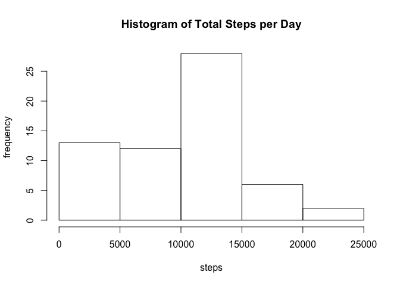

```r
hist(total_daily_steps$daily_steps, main = "Histogram of Total Steps per Day", xlab="steps", ylab="frequency")
```

**3. Mean and median of steps per day**

```r
avg_steps <- mean(total_daily_steps$daily_steps)
median_steps <- median(total_daily_steps$daily_steps)
```

- Average steps per day is 9354.2295
- Median steps per day is 10395

## What is the average daily activity pattern?

**1. Make a time series plot, of the 5-minute interval (x-axis) and the average number of steps taken, averaged across all days (y-axis)**

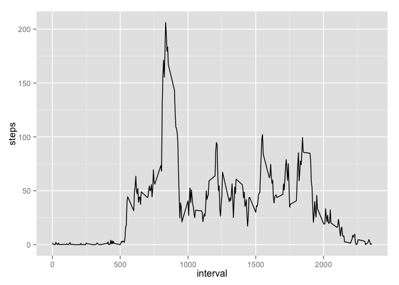

```r
steps_by_interval <- summarise(
  group_by(data, interval),
  steps = mean(steps, na.rm=TRUE)
)

qplot(interval, steps, data=steps_by_interval, geom=c('line'))
```

**2. Which 5-minute interval, on average across all the days in the dataset, contains the maximum number of steps?**

```r
max_interval <- filter(steps_by_interval, steps == max(steps_by_interval$steps))$interval[1]
```

The interval with the highest average steps is 835.

## Imputing missing values

```r
missing_values <- dim(filter(data, is.na(steps)))[1]
```

**1. Calculate and report the total number of missing values in the dataset (i.e. the total number of rows with NAs)**  
- There are 2304 missing values in the dataset.

**2. Devise a strategy for filling in all of the missing values in the dataset.**  
A strategy to fill in all of the missing values is to use the daily average of that interval.

**3. Create a new dataset that is equal to the original dataset but with the missing data filled in.**

```r
data_fillna <- merge(data, steps_by_interval, by = c('interval'))
data_fillna$steps <- data_fillna$steps.x
data_fillna$steps[is.na(data_fillna$steps.x)] <- data_fillna$steps.y[is.na(data_fillna$steps.x)]

data_fillna <- data_fillna[, c('steps', 'date', 'interval')]
```

**4. Make a histogram of the total number of steps taken each day and Calculate and report the mean and median total number of steps taken per day**

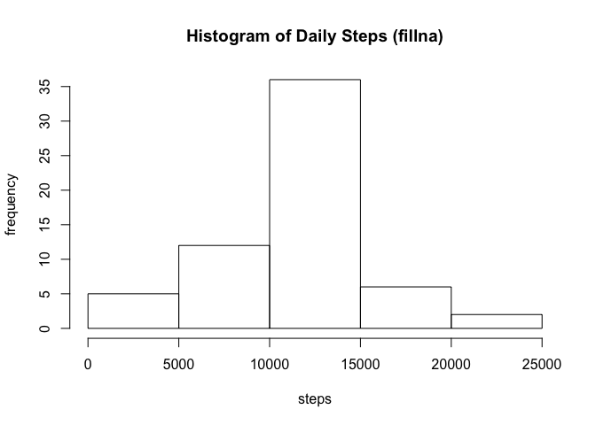

```r
total_daily_fillna <- summarise(group_by(data_fillna, date),
                                steps = sum(steps)
                                )
avg_daily_fillna <- mean(total_daily_fillna$steps)
median_daily_fillna <- median(total_daily_fillna$steps)

hist(total_daily_fillna$steps, main='Histogram of Daily Steps (fillna)', xlab = 'steps', ylab = 'frequency')
```

- The average daily steps after fill na becomes: 1.0766 × 10<sup>4</sup>
- The median daily steps after fill na becomes: 1.0766 × 10<sup>4</sup>
- Imputing the missing values had more impact on the mean than the median, and lowered the variance in estimating daily average steps.

## Are there differences in activity patterns between weekdays and weekends?

**1. Creating a new weekend flag variable**

```r
data_fillna$weekday <- 'weekday'
data_fillna$weekday[weekdays(as.Date(data_fillna$date)) == 'Saturday'] <- 'weekend'
data_fillna$weekday[weekdays(as.Date(data_fillna$date)) == 'Sunday'] <- 'weekend'
```

**2. Panel plot of the intervals**

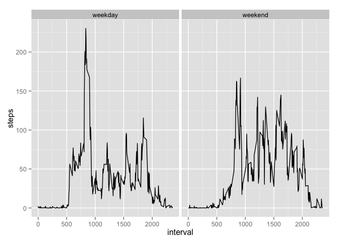

```r
data_by_weekday <- summarise(
  group_by(data_fillna, weekday, interval),
  steps = mean(steps)
  )
qplot(interval, steps, facets = .~weekday, data=data_by_weekday, geom=c('line'))
```